# Reproducible Data Analysis Project

u3220939

2023-04-27

# 1.) INTRODUCTION

#### a) Basketball is a famous sport played around the world and has aslo been part of the Olympic Games since 1936. It requires two teams of five players each, trying to score points by throwing a ball through a basket, which is set up at 10 feet high on a backboard at each end of the court.

In basketball, there are five positions, each with particular requirements and responsibilities.

Point guard (PG): Usually the smallest player on the team, is responsible for bringing the ball up the court and initiating the team’s offense. Skills - quick, agile, passing.

Shooting guard (SG): The shooting guard’s role is to score points by shooting the ball from mid-range or beyond the three-point line. Skills - dribble, passing, scoring.

Small forward (SF): The small forward is an adaptable player, making them an important part of both the offense and defense. Skills - shoot, pass, rebound.

Power forward (PF): The power forward is a strong and athletic player who plays close to the hoop. Skills- rebounding, defending, scoring in the low post.

Center (C): The center is the tallest player on the team and they need to be strong and have excellent footwork. Skills - defending the rim, rebounding, and scoring in the low post.

#### b)Scenario:

As a data analyst for the Chicago Bulls, I have been assigned to find the best starting players for the team within a limited budget. The team’s performance in the season before was not up to the level, and their budget for player contracts in the upcoming season is low compared to other teams in the league. My goal is to analyze the available data and find the best possible players for each position.

#### d)Justification and Importance:

The Chicago Bulls’ performance in the previous season was below expectations, and the squad is looking for ways to improve its performance in the upcoming season. As a result, finding the best possible players for each position within the team’s budget is key. This project is important as it utilizes data analysis to provide objective intuition to the team’s innovative process and helps to scout players that can significantly contribute to the team’s success. In addition to that, this project can serve as a guide for other teams in the NBA who are also looking to optimize their player selection process within a budget constraint.

# 2.) Preparing the Data

```r
#loading the required libraries

library(dplyr)
library(tidyverse)
library(readr)

# reading the given data

player_stats <- read_csv("2018-19_nba_player-statistics.csv")
club_stats1 <- read_csv("2018-19_nba_team-statistics_1.csv")
```

```
## ──────────────────────────────────────────────────────── Delimiter: "," chr
## (1): Team dbl (21): Rk, Age, W, L, PW, PL, MOV, SOS, SRS, ORtg, DRtg, NRtg,
## Pace, FTr,... lgl (3): ...23, ...24, ...25
```

```r
club_stats2 <- read_csv("2018-19_nba_team-statistics_2.csv")
player_payroll <- read_csv("2019-20_nba_team-payroll.csv")
player_salary <- read_csv("2018-19_nba_player-salaries.csv")
view(player_stats)
```

## CLEANING the data

```r
str(player_stats)            #checking the structure of the data
```

```
## spec_tbl_df [708 × 29] (S3: spec_tbl_df/tbl_df/tbl/data.frame)
##  $ player_name: chr [1:708] "Alex Abrines" "Quincy Acy" "Jaylen Adams" "Steven Adams" ...
##  $ Pos        : chr [1:708] "SG" "PF" "PG" "C" ...
##  $ Age        : num [1:708] 25 28 22 25 21 21 25 33 21 23 ...
##  $ Tm         : chr [1:708] "OKC" "PHO" "ATL" "OKC" ...
##  $ G          : num [1:708] 31 10 34 80 82 19 7 81 10 38 ...
##  $ GS         : num [1:708] 2 0 1 80 28 3 0 81 1 2 ...
##  $ MP         : num [1:708] 588 123 428 2669 1913 ...
##  $ FG         : num [1:708] 56 4 38 481 280 11 3 684 13 67 ...
##  $ FGA        : num [1:708] 157 18 110 809 486 ...
##  $ FG%        : num [1:708] 0.357 0.222 0.345 0.595 0.576 0.306 0.3 0.519 0.333 0.376 ...
##  $ 3P         : num [1:708] 41 2 25 0 3 6 0 10 3 32 ...
##  $ 3PA        : num [1:708] 127 15 74 2 15 23 4 42 12 99 ...
##  $ 3P%        : num [1:708] 0.323 0.133 0.338 0 0.2 0.261 0 0.238 0.25 0.323 ...
##  $ 2P         : num [1:708] 15 2 13 481 277 5 3 674 10 35 ...
##  $ 2PA        : num [1:708] 30 3 36 807 471 ...
##  $ 2P%        : num [1:708] 0.5 0.667 0.361 0.596 0.588 0.385 0.5 0.528 0.37 0.443 ...
##  $ eFG%       : num [1:708] 0.487 0.278 0.459 0.595 0.579 0.389 0.3 0.522 0.372 0.466 ...
##  $ FT         : num [1:708] 12 7 7 146 166 4 1 349 8 45 ...
##  $ FTA        : num [1:708] 13 10 9 292 226 4 2 412 12 60 ...
##  $ FT%        : num [1:708] 0.923 0.7 0.778 0.5 0.735 1 0.5 0.847 0.667 0.75 ...
##  $ ORB        : num [1:708] 5 3 11 391 165 3 1 251 11 3 ...
##  $ DRB        : num [1:708] 43 22 49 369 432 16 3 493 15 20 ...
##  $ TRB        : num [1:708] 48 25 60 760 597 19 4 744 26 23 ...
##  $ AST        : num [1:708] 20 8 65 124 184 5 6 194 13 25 ...
##  $ STL        : num [1:708] 17 1 14 117 71 1 2 43 1 6 ...
##  $ BLK        : num [1:708] 6 4 5 76 65 4 0 107 0 6 ...
##  $ TOV        : num [1:708] 14 4 28 135 121 6 2 144 8 33 ...
##  $ PF         : num [1:708] 53 24 45 204 203 13 4 179 7 47 ...
##  $ PTS        : num [1:708] 165 17 108 1108 729 ...
##  - attr(*, "spec")=
##   .. cols(
##   ..   player_name = col_character(),
##   ..   Pos = col_character(),
##   ..   Age = col_double(),
##   ..   Tm = col_character(),
##   ..   G = col_double(),
##   ..   GS = col_double(),
##   ..   MP = col_double(),
##   ..   FG = col_double(),
```

[output cut: 8 more lines]

```
##   ..   `eFG%` = col_double(),
##   ..   FT = col_double(),
##   ..   FTA = col_double(),
##   ..   `FT%` = col_double(),
##   ..   ORB = col_double(),
##   ..   DRB = col_double(),
##   ..   TRB = col_double(),
##   ..   AST = col_double(),
##   ..   STL = col_double(),
##   ..   BLK = col_double(),
##   ..   TOV = col_double(),
##   ..   PF = col_double(),
##   ..   PTS = col_double()
##   .. )
##  - attr(*, "problems")=<externalptr>
```

```r
head(player_stats)           #checking the first 6 rows
```

```
## # A tibble: 6 × 29
##   player_name  Pos     Age Tm        G    GS    MP    FG   FGA `FG%`  `3P` `3PA`
##   <chr>        <chr> <dbl> <chr> <dbl> <dbl> <dbl> <dbl> <dbl> <dbl> <dbl> <dbl>
## 1 Alex Abrines SG       25 OKC      31     2   588    56   157 0.357    41   127
## 2 Quincy Acy   PF       28 PHO      10     0   123     4    18 0.222     2    15
## 3 Jaylen Adams PG       22 ATL      34     1   428    38   110 0.345    25    74
## 4 Steven Adams C        25 OKC      80    80  2669   481   809 0.595     0     2
## 5 Bam Adebayo  C        21 MIA      82    28  1913   280   486 0.576     3    15
## 6 Deng Adel    SF       21 CLE      19     3   194    11    36 0.306     6    23
## # … with 17 more variables: `3P%` <dbl>, `2P` <dbl>, `2PA` <dbl>, `2P%` <dbl>,
## #   `eFG%` <dbl>, FT <dbl>, FTA <dbl>, `FT%` <dbl>, ORB <dbl>, DRB <dbl>,
## #   TRB <dbl>, AST <dbl>, STL <dbl>, BLK <dbl>, TOV <dbl>, PF <dbl>, PTS <dbl>
```

```r
tail(player_stats)           #checking the last 6 rows
```

```
## # A tibble: 6 × 29
##   player_name Pos     Age Tm        G    GS    MP    FG   FGA `FG%`  `3P` `3PA`
##   <chr>       <chr> <dbl> <chr> <dbl> <dbl> <dbl> <dbl> <dbl> <dbl> <dbl> <dbl>
## 1 Ivica Zubac C        21 LAL      33    12   516   112   193 0.58      0     0
## 2 Ivica Zubac C        21 TOT      59    37  1040   212   379 0.559     0     0
## 3 Dario Saric PF       24 PHI      13    13   396    48   132 0.364    21    70
## 4 Dario Saric PF       24 MIN      68    28  1627   256   564 0.454    97   253
## 5 Dario Saric PF       24 TOT      81    41  2023   304   696 0.437   118   323
## 6 Ante Zizic  C        22 CLE      59    25  1082   183   331 0.553     0     0
## # … with 17 more variables: `3P%` <dbl>, `2P` <dbl>, `2PA` <dbl>, `2P%` <dbl>,
## #   `eFG%` <dbl>, FT <dbl>, FTA <dbl>, `FT%` <dbl>, ORB <dbl>, DRB <dbl>,
## #   TRB <dbl>, AST <dbl>, STL <dbl>, BLK <dbl>, TOV <dbl>, PF <dbl>, PTS <dbl>
```

```r
dim(player_stats)
```

```
## [1] 708  29
```

```r
summary(player_stats)
```

```
##  player_name            Pos                 Age             Tm
##  Length:708         Length:708         Min.   :19.00   Length:708
##  Class :character   Class :character   1st Qu.:23.00   Class :character
##  Mode  :character   Mode  :character   Median :26.00   Mode  :character
##                                        Mean   :26.14
##                                        3rd Qu.:29.00
##                                        Max.   :42.00
##
##        G               GS              MP               FG
##  Min.   : 1.00   Min.   : 0.00   Min.   :   1.0   Min.   :  0.0
##  1st Qu.:19.00   1st Qu.: 0.00   1st Qu.: 245.2   1st Qu.: 32.0
##  Median :44.00   Median : 6.00   Median : 788.0   Median :108.5
##  Mean   :42.88   Mean   :19.85   Mean   : 972.3   Mean   :162.6
##  3rd Qu.:68.00   3rd Qu.:32.00   3rd Qu.:1579.5   3rd Qu.:236.2
##  Max.   :82.00   Max.   :82.00   Max.   :3028.0   Max.   :843.0
##
##       FGA               FG%               3P              3PA
##  Min.   :   0.00   Min.   :0.0000   Min.   :  0.00   Min.   :   0.0
##  1st Qu.:  72.75   1st Qu.:0.4000   1st Qu.:  4.00   1st Qu.:  13.0
##  Median : 256.00   Median :0.4340   Median : 26.00   Median :  79.0
##  Mean   : 355.42   Mean   :0.4373   Mean   : 46.12   Mean   : 130.1
##  3rd Qu.: 526.00   3rd Qu.:0.4850   3rd Qu.: 69.25   3rd Qu.: 200.0
##  Max.   :1909.00   Max.   :1.0000   Max.   :378.00   Max.   :1028.0
##                    NA's   :6
##       3P%              2P             2PA              2P%
##  Min.   :0.000   Min.   :  0.0   Min.   :   0.0   Min.   :0.0000
##  1st Qu.:0.286   1st Qu.: 18.0   1st Qu.:  40.0   1st Qu.:0.4500
##  Median :0.335   Median : 71.0   Median : 138.0   Median :0.5000
##  Mean   :0.315   Mean   :116.5   Mean   : 225.3   Mean   :0.4923
##  3rd Qu.:0.372   3rd Qu.:164.2   3rd Qu.: 314.5   3rd Qu.:0.5480
##  Max.   :1.000   Max.   :674.0   Max.   :1277.0   Max.   :1.0000
##  NA's   :47                                       NA's   :15
##       eFG%              FT              FTA              FT%
##  Min.   :0.0000   Min.   :  0.00   Min.   :  0.00   Min.   :0.0000
##  1st Qu.:0.4700   1st Qu.: 11.00   1st Qu.: 15.00   1st Qu.:0.6840
##  Median :0.5080   Median : 39.00   Median : 51.00   Median :0.7630
##  Mean   :0.5002   Mean   : 69.88   Mean   : 91.01   Mean   :0.7396
##  3rd Qu.:0.5517   3rd Qu.: 94.00   3rd Qu.:123.00   3rd Qu.:0.8250
##  Max.   :1.5000   Max.   :754.00   Max.   :858.00   Max.   :1.0000
##  NA's   :6                                          NA's   :43
```

[output cut: 9 more lines]

```
##  Min.   :  0.00   Min.   :  0.00   Min.   :  0.00   Min.   :  0.0
##  1st Qu.:  7.00   1st Qu.:  3.00   1st Qu.: 11.00   1st Qu.: 24.0
##  Median : 21.00   Median : 10.00   Median : 36.00   Median : 73.5
##  Mean   : 30.58   Mean   : 19.29   Mean   : 53.52   Mean   : 84.1
##  3rd Qu.: 46.00   3rd Qu.: 25.00   3rd Qu.: 75.00   3rd Qu.:131.2
##  Max.   :170.00   Max.   :199.00   Max.   :387.00   Max.   :292.0
##
##       PTS
##  Min.   :   0.00
##  1st Qu.:  82.75
##  Median : 294.00
##  Mean   : 441.29
##  3rd Qu.: 634.00
##  Max.   :2818.00
##
```

### Checking the Missing values from the data set.

#### Missing values can occur in data due to various reasons such as incomplete data recording, measurement errors.

```r
player_stats%>% summarise_all(funs(sum(is.na(.)))) %>%
 gather() %>% filter(value > 0)
```

```
## # A tibble: 5 × 2
##   key   value
##   <chr> <int>
## 1 FG%       6
## 2 3P%      47
## 3 2P%      15
## 4 eFG%      6
## 5 FT%      43
```

#### After checking the dataset 5 variables out of 29 have missing values and all five key in analyising the players.

```r
player_stats <- player_stats %>% mutate_if(is.numeric, function(x) ifelse(is.na(x), median(x, na.rm = T), x))

head(player_stats)
```

```
## # A tibble: 6 × 29
##   player_name  Pos     Age Tm        G    GS    MP    FG   FGA `FG%`  `3P` `3PA`
##   <chr>        <chr> <dbl> <chr> <dbl> <dbl> <dbl> <dbl> <dbl> <dbl> <dbl> <dbl>
## 1 Alex Abrines SG       25 OKC      31     2   588    56   157 0.357    41   127
## 2 Quincy Acy   PF       28 PHO      10     0   123     4    18 0.222     2    15
## 3 Jaylen Adams PG       22 ATL      34     1   428    38   110 0.345    25    74
## 4 Steven Adams C        25 OKC      80    80  2669   481   809 0.595     0     2
## 5 Bam Adebayo  C        21 MIA      82    28  1913   280   486 0.576     3    15
## 6 Deng Adel    SF       21 CLE      19     3   194    11    36 0.306     6    23
## # … with 17 more variables: `3P%` <dbl>, `2P` <dbl>, `2PA` <dbl>, `2P%` <dbl>,
## #   `eFG%` <dbl>, FT <dbl>, FTA <dbl>, `FT%` <dbl>, ORB <dbl>, DRB <dbl>,
## #   TRB <dbl>, AST <dbl>, STL <dbl>, BLK <dbl>, TOV <dbl>, PF <dbl>, PTS <dbl>
```

```r
tail(player_stats)
```

```
## # A tibble: 6 × 29
##   player_name Pos     Age Tm        G    GS    MP    FG   FGA `FG%`  `3P` `3PA`
##   <chr>       <chr> <dbl> <chr> <dbl> <dbl> <dbl> <dbl> <dbl> <dbl> <dbl> <dbl>
## 1 Ivica Zubac C        21 LAL      33    12   516   112   193 0.58      0     0
## 2 Ivica Zubac C        21 TOT      59    37  1040   212   379 0.559     0     0
## 3 Dario Saric PF       24 PHI      13    13   396    48   132 0.364    21    70
## 4 Dario Saric PF       24 MIN      68    28  1627   256   564 0.454    97   253
## 5 Dario Saric PF       24 TOT      81    41  2023   304   696 0.437   118   323
## 6 Ante Zizic  C        22 CLE      59    25  1082   183   331 0.553     0     0
## # … with 17 more variables: `3P%` <dbl>, `2P` <dbl>, `2PA` <dbl>, `2P%` <dbl>,
## #   `eFG%` <dbl>, FT <dbl>, FTA <dbl>, `FT%` <dbl>, ORB <dbl>, DRB <dbl>,
## #   TRB <dbl>, AST <dbl>, STL <dbl>, BLK <dbl>, TOV <dbl>, PF <dbl>, PTS <dbl>
```

```r
summary(player_stats)
```

```
##  player_name            Pos                 Age             Tm
##  Length:708         Length:708         Min.   :19.00   Length:708
##  Class :character   Class :character   1st Qu.:23.00   Class :character
##  Mode  :character   Mode  :character   Median :26.00   Mode  :character
##                                        Mean   :26.14
##                                        3rd Qu.:29.00
##                                        Max.   :42.00
##        G               GS              MP               FG
##  Min.   : 1.00   Min.   : 0.00   Min.   :   1.0   Min.   :  0.0
##  1st Qu.:19.00   1st Qu.: 0.00   1st Qu.: 245.2   1st Qu.: 32.0
##  Median :44.00   Median : 6.00   Median : 788.0   Median :108.5
##  Mean   :42.88   Mean   :19.85   Mean   : 972.3   Mean   :162.6
##  3rd Qu.:68.00   3rd Qu.:32.00   3rd Qu.:1579.5   3rd Qu.:236.2
##  Max.   :82.00   Max.   :82.00   Max.   :3028.0   Max.   :843.0
##       FGA               FG%               3P              3PA
##  Min.   :   0.00   Min.   :0.0000   Min.   :  0.00   Min.   :   0.0
##  1st Qu.:  72.75   1st Qu.:0.4000   1st Qu.:  4.00   1st Qu.:  13.0
##  Median : 256.00   Median :0.4340   Median : 26.00   Median :  79.0
##  Mean   : 355.42   Mean   :0.4373   Mean   : 46.12   Mean   : 130.1
##  3rd Qu.: 526.00   3rd Qu.:0.4843   3rd Qu.: 69.25   3rd Qu.: 200.0
##  Max.   :1909.00   Max.   :1.0000   Max.   :378.00   Max.   :1028.0
##       3P%               2P             2PA              2P%
##  Min.   :0.0000   Min.   :  0.0   Min.   :   0.0   Min.   :0.0000
##  1st Qu.:0.2908   1st Qu.: 18.0   1st Qu.:  40.0   1st Qu.:0.4530
##  Median :0.3350   Median : 71.0   Median : 138.0   Median :0.5000
##  Mean   :0.3164   Mean   :116.5   Mean   : 225.3   Mean   :0.4925
##  3rd Qu.:0.3690   3rd Qu.:164.2   3rd Qu.: 314.5   3rd Qu.:0.5480
##  Max.   :1.0000   Max.   :674.0   Max.   :1277.0   Max.   :1.0000
##       eFG%              FT              FTA              FT%
##  Min.   :0.0000   Min.   :  0.00   Min.   :  0.00   Min.   :0.000
##  1st Qu.:0.4708   1st Qu.: 11.00   1st Qu.: 15.00   1st Qu.:0.690
##  Median :0.5080   Median : 39.00   Median : 51.00   Median :0.763
##  Mean   :0.5003   Mean   : 69.88   Mean   : 91.01   Mean   :0.741
##  3rd Qu.:0.5510   3rd Qu.: 94.00   3rd Qu.:123.00   3rd Qu.:0.820
##  Max.   :1.5000   Max.   :754.00   Max.   :858.00   Max.   :1.000
##       ORB              DRB             TRB               AST
##  Min.   :  0.00   Min.   :  0.0   Min.   :   0.00   Min.   :  0.00
##  1st Qu.:  7.00   1st Qu.: 32.0   1st Qu.:  41.75   1st Qu.: 16.00
##  Median : 23.00   Median :102.5   Median : 128.50   Median : 56.00
##  Mean   : 41.01   Mean   :139.1   Mean   : 180.12   Mean   : 96.32
##  3rd Qu.: 54.00   3rd Qu.:199.0   3rd Qu.: 258.00   3rd Qu.:124.25
##  Max.   :423.00   Max.   :809.0   Max.   :1232.00   Max.   :784.00
##       STL              BLK              TOV               PF
##  Min.   :  0.00   Min.   :  0.00   Min.   :  0.00   Min.   :  0.0
##  1st Qu.:  7.00   1st Qu.:  3.00   1st Qu.: 11.00   1st Qu.: 24.0
##  Median : 21.00   Median : 10.00   Median : 36.00   Median : 73.5
##  Mean   : 30.58   Mean   : 19.29   Mean   : 53.52   Mean   : 84.1
##  3rd Qu.: 46.00   3rd Qu.: 25.00   3rd Qu.: 75.00   3rd Qu.:131.2
##  Max.   :170.00   Max.   :199.00   Max.   :387.00   Max.   :292.0
##       PTS
##  Min.   :   0.00
##  1st Qu.:  82.75
##  Median : 294.00
##  Mean   : 441.29
##  3rd Qu.: 634.00
##  Max.   :2818.00
```

## PLAYER GAME SCORE(PGS)

### A player’s game score is a metric used to evaluate their performance in a given game. It takes into account various statistics such as points scored, rebounds, assists, steals, blocks, and turnovers.

### The resulting score provides a measure of the player’s overall contribution to their team’s performance in the game. A higher game score indicates a more productive and impactful performance by the player, while a lower score suggests a less effective performance. However, it’s important to note that this metric doesn’t account for intangible contributions such as leadership, hustle, and teamwork.

### RENAMING the variables for better usage.

```r
player_stats <- rename(player_stats,
 Position="Pos",
Team='Tm',
Games='G',
Games_started='GS',
Minutes_playerd='MP',
Field_Goal='FG',
Field_Goal_per='FG%',
Free_Throw='FT',
Of_Rebound='ORB',
Df_Rebound='DRB',
Assists='AST',
Steals='STL',
Blocks='BLK',
Total_Rebounds='TRB',
Player_Fouls='PF',
Turn_Over='TOV',
Points='PTS',
Three_point_per='3P%',
Two_point_per='2P%')
```

### Filtering the data based on the games played by the players in the season 2018-19

```r
player_stats <- subset(player_stats, Games > 20)
head(player_stats)
```

```
## # A tibble: 6 × 29
##   player…¹ Posit…²   Age Team  Games Games…³ Minut…⁴ Field…⁵   FGA Field…⁶  `3P`
##   <chr>    <chr>   <dbl> <chr> <dbl>   <dbl>   <dbl>   <dbl> <dbl>   <dbl> <dbl>
## 1 Alex Ab… SG         25 OKC      31       2     588      56   157   0.357    41
## 2 Jaylen … PG         22 ATL      34       1     428      38   110   0.345    25
## 3 Steven … C          25 OKC      80      80    2669     481   809   0.595     0
## 4 Bam Ade… C          21 MIA      82      28    1913     280   486   0.576     3
## 5 LaMarcu… C          33 SAS      81      81    2687     684  1319   0.519    10
## 6 Grayson… SG         23 UTA      38       2     416      67   178   0.376    32
## # … with 18 more variables: `3PA` <dbl>, Three_point_per <dbl>, `2P` <dbl>,
## #   `2PA` <dbl>, Two_point_per <dbl>, `eFG%` <dbl>, Free_Throw <dbl>,
## #   FTA <dbl>, `FT%` <dbl>, Of_Rebound <dbl>, Df_Rebound <dbl>,
## #   Total_Rebounds <dbl>, Assists <dbl>, Steals <dbl>, Blocks <dbl>,
## #   Turn_Over <dbl>, Player_Fouls <dbl>, Points <dbl>, and abbreviated variable
## #   names ¹player_name, ²Position, ³Games_started, ⁴Minutes_playerd,
## #   ⁵Field_Goal, ⁶Field_Goal_per
```

#### The NBA season is long, with each team playing 82 games over several months. By selecting players who played more than 20 games in the previous season, we can ensure that we have a reasonable sample size to work with.

#### Players who have played more than 20 games in the previous season are likely to have established a consistent level of performance, making it easier to identify trends or changes in their performance over time.

## Caluculating the Player Game Score(PGS)

```r
player_stats <- player_stats %>% mutate(game_score=Points+Assists+Steals+Blocks-Turn_Over-Player_Fouls)
player_stats <- player_stats %>% mutate(Player_Game_Score=game_score/Games)

view(player_stats)
```

#### Sorting the data using the variable Player game score

```r
player_stats <- player_stats[order(-player_stats$Player_Game_Score),]

# Convert Pos column to factor
player_stats$Position <- as.factor(player_stats$Position)

# Spliting Pos column into multiple rows
player_stats <- player_stats %>%
  separate_rows(Position, sep = '-') %>%
  mutate(Position = trimws(Position))

view(player_stats)
```

# 3.) Exploratory data Analysis

### Frequency distribution

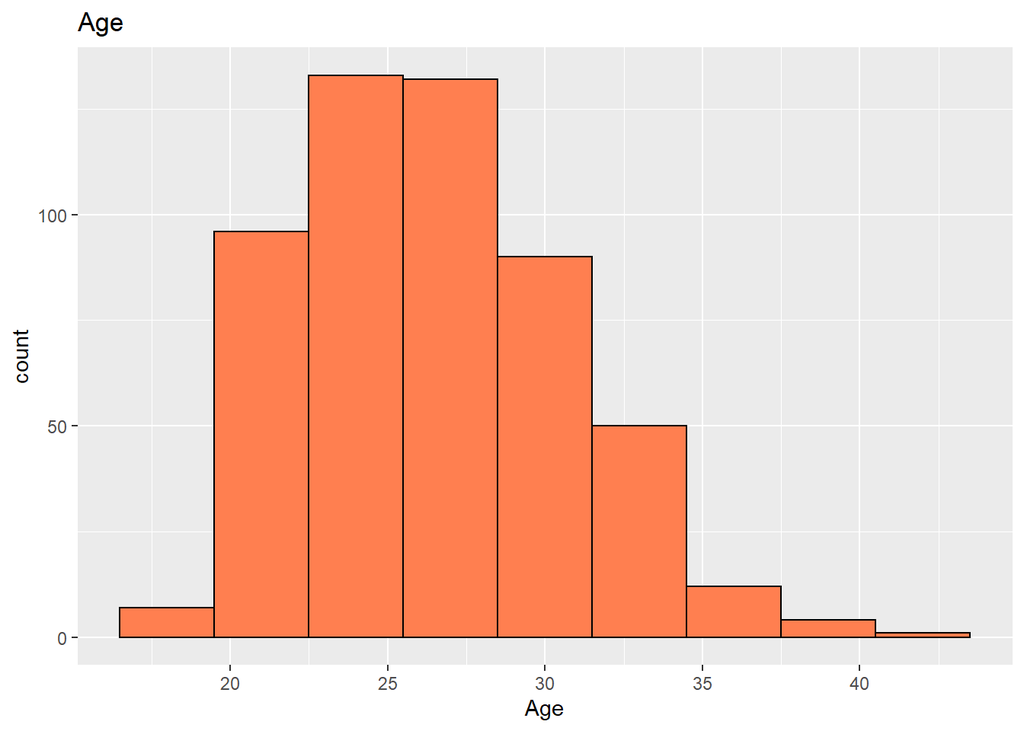

```r
ggplot(data = player_stats) +
geom_histogram(mapping = aes(x = Age), colour = "black", fill = "coral",binwidth = 3)+
 ggtitle("Age")
```

#### The graph represents the age distribution of players, with the x-axis indicating age and the y-axis showing the frequency of each age. It can be useful for making decisions regarding player recruitment and team composition.

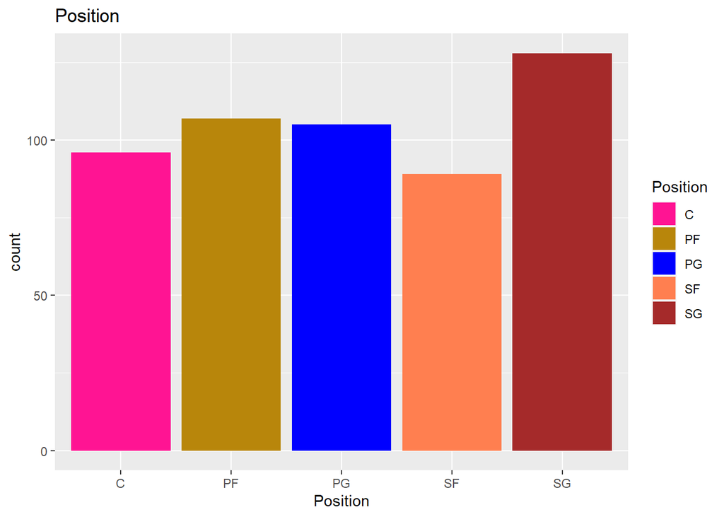

```r
ggplot(player_stats, aes(x = Position, fill = Position)) +
  geom_bar() +
  ggtitle("Position") +
  scale_fill_manual(values = c("deeppink", "darkgoldenrod", "blue", "coral", "brown"))
```

####

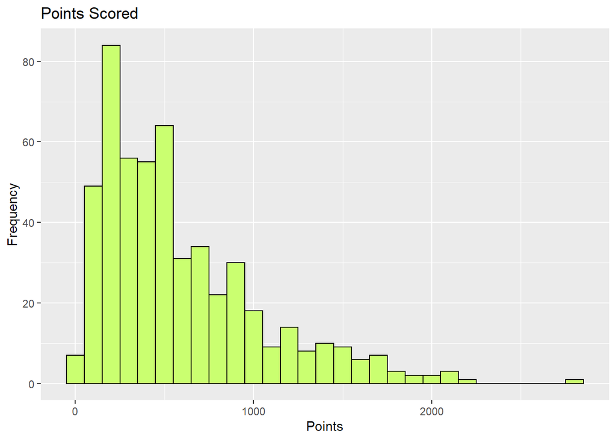

```r
ggplot(player_stats, aes(x = Points)) +
  geom_histogram(binwidth = 100, colour = "black", fill = "darkolivegreen1") +
  labs(x = "Points", y = "Frequency", title = "Points Scored")
```

####

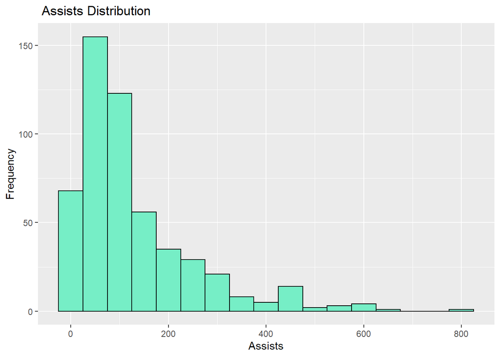

```r
ggplot(player_stats, aes(x = Assists)) +
  geom_histogram(binwidth = 50, colour = "black", fill = "aquamarine2") +
  labs(x = "Assists", y = "Frequency", title = " Assists Distribution")
```

####

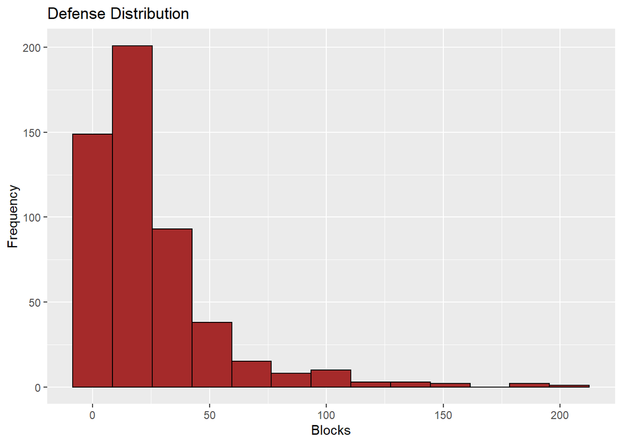

```r
ggplot(player_stats, aes(x = Blocks)) +
  geom_histogram(binwidth = 17, colour = "black", fill = "brown") +
  labs(x = "Blocks", y = "Frequency", title = "Defense Distribution")
```

####

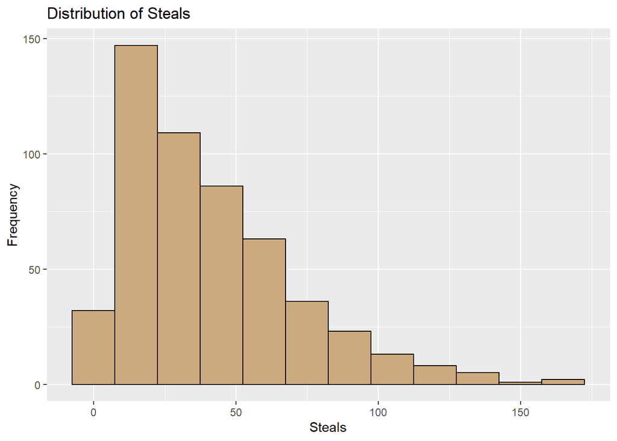

```r
ggplot(player_stats, aes(x = Steals)) +
  geom_histogram(binwidth = 15, colour = "black", fill = "burlywood3") +
  labs(x = "Steals", y = "Frequency", title = "Distribution of Steals")
```

####

## Comparing POSITION with some of the importanta attributes in basketball.

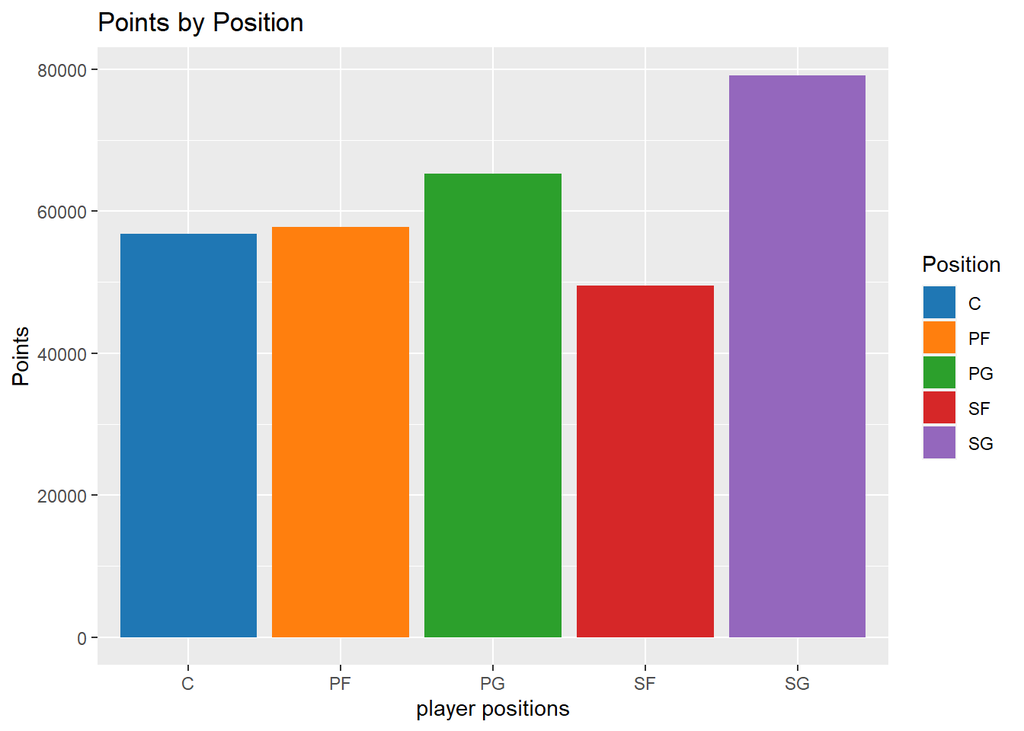

```r
ggplot(player_stats, aes(x = Position, y = Points, fill = Position)) +
  geom_bar(stat = "identity") +
  labs(title = "Points by Position", x = "player positions", y = "Points") +
  scale_fill_manual(values = c("#1F77B4", "#FF7F0E", "#2CA02C", "#D62728", "#9467BD"))
```

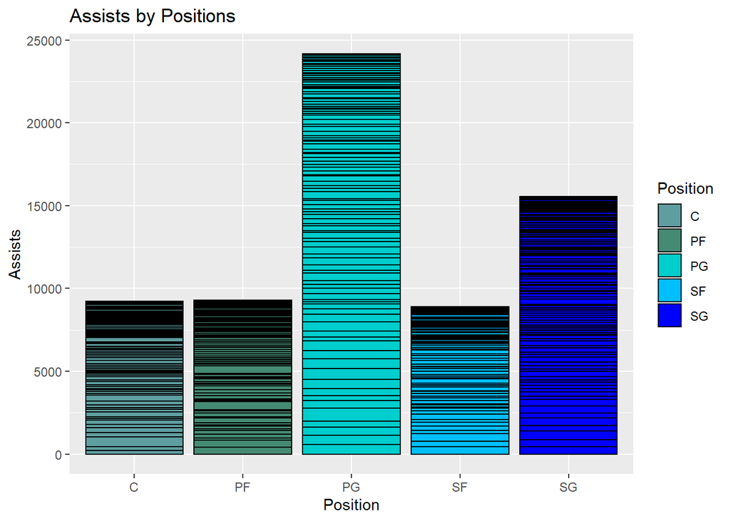

```r
ggplot(player_stats, aes(x = Position, y = Assists, fill = Position)) +
  geom_bar(stat = "identity", color = "black") +
  xlab("Position") +
  ylab("Assists") +
   scale_fill_manual(values = c("cadetblue", "aquamarine4", "cyan3", "deepskyblue", "blue"))+
  ggtitle("Assists by Positions")
```

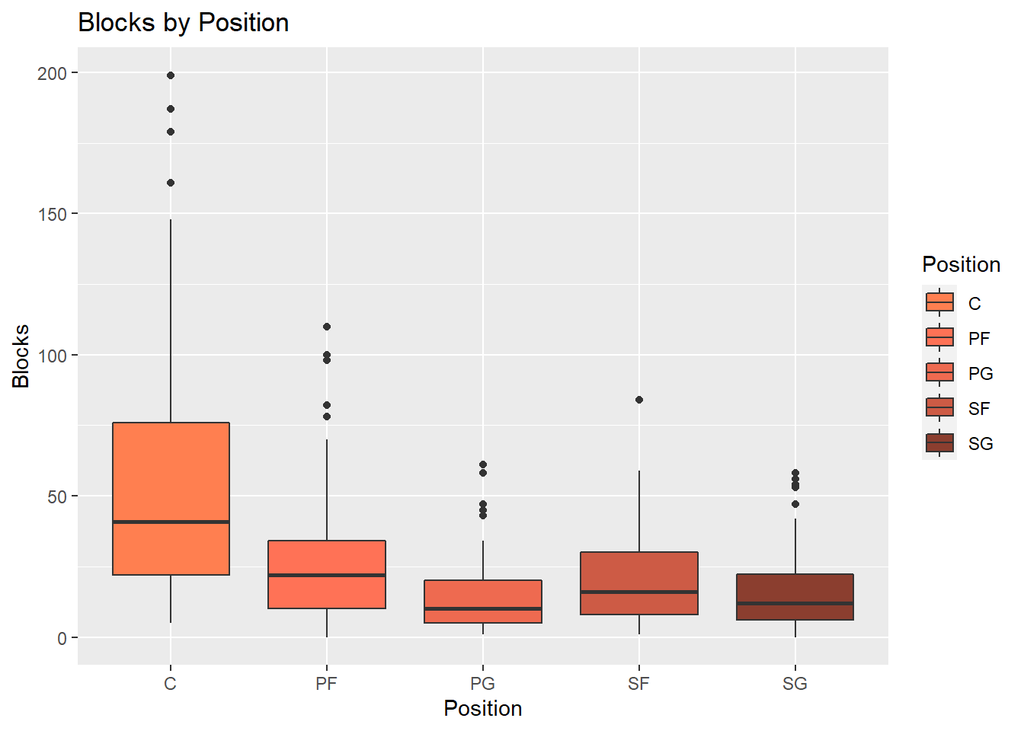

```r
ggplot(player_stats, aes(x = Position, y = Blocks, fill = Position)) +
  geom_boxplot() +
  scale_fill_manual(values = c("coral", "coral1", "coral2", "coral3", "coral4")) +
  labs(title = "Blocks by Position", x = "Position", y = "Blocks")
```

####

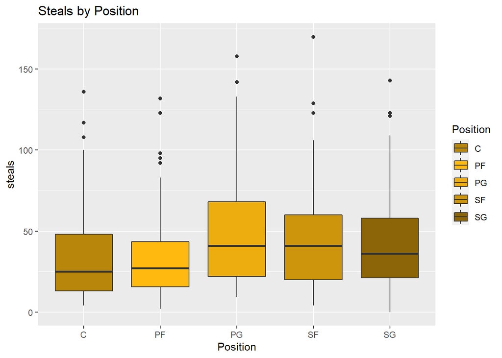

```r
ggplot(player_stats, aes(x = Position, y = Steals, fill = Position)) +
  geom_boxplot() +
  scale_fill_manual(values = c("darkgoldenrod", "darkgoldenrod1", "darkgoldenrod2", "darkgoldenrod3", "darkgoldenrod4")) +
  labs(title = "Steals by Position", x = "Position", y = "steals")
```

## PATTERNS-TRENDS of variables

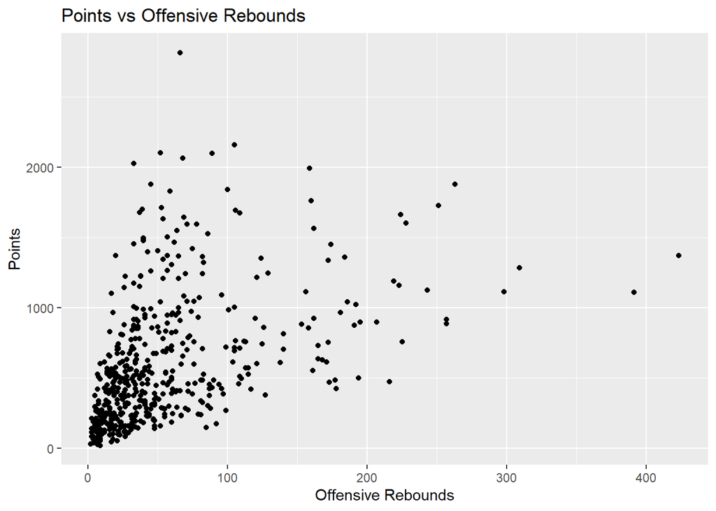

```r
ggplot(player_stats, aes(x = Of_Rebound, y = Points)) +
  geom_point() +
  xlab("Offensive Rebounds") +
  ylab("Points") +
  ggtitle("Points vs Offensive Rebounds")
```

#### Each point on the scatter plot represents a player, with their offensive rebounds plotted on the x-axis and their points plotted on the y-axis. There is a positive correlation between points and offensive rebounds.

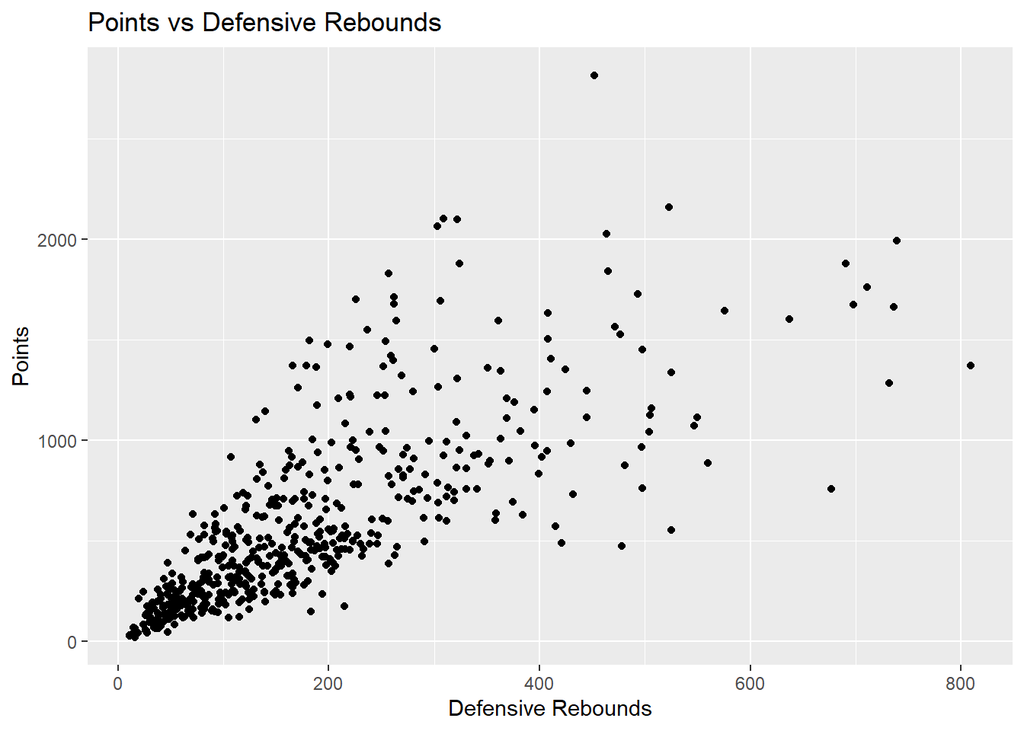

```r
  ggplot(player_stats, aes(x = Df_Rebound, y = Points)) +
  geom_point() +
  xlab("Defensive Rebounds") +
  ylab("Points") +
  ggtitle("Points vs Defensive Rebounds")
```

#### We can see if there is a pattern or correlation between the number of points a player scores and the number of defensive rebounds they make. There is a positive correlation between these two variables, it means that players who score more points also tend to have more defensive rebounds.

## Target- Variable VS Variables

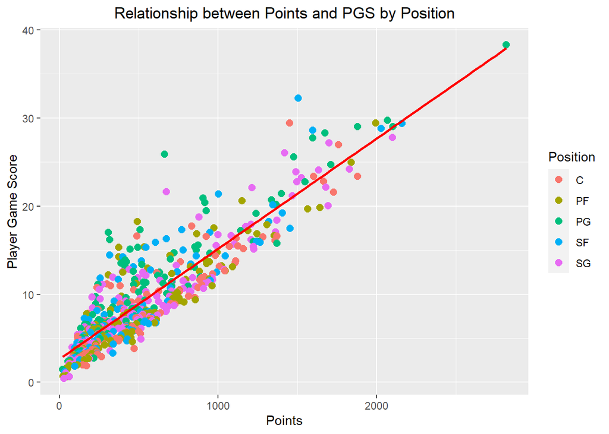

```r
ggplot(player_stats, aes(x = Points, y = Player_Game_Score, color = Position)) +
  geom_point(size = 2.5) +
   geom_smooth(method = "lm", color = "red", se = FALSE)+
  xlab("Points") + ylab("Player Game Score") +
  ggtitle("Relationship between Points and PGS by Position") +
  theme(plot.title = element_text(hjust = 0.5))
```

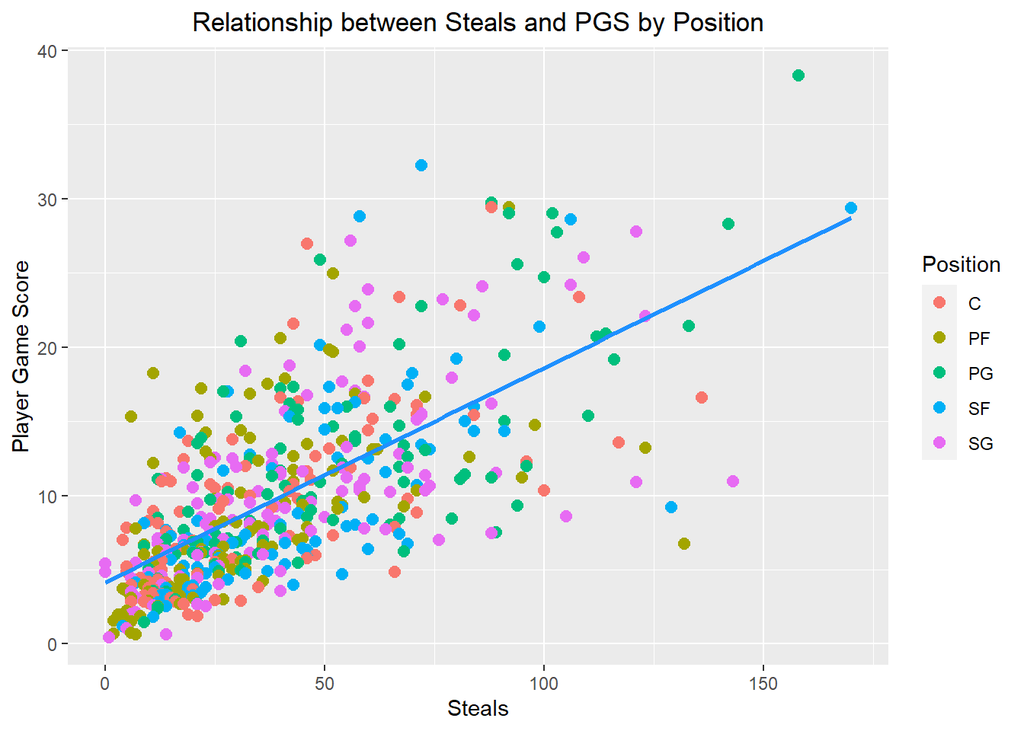

```r
ggplot(player_stats, aes(x = Steals, y = Player_Game_Score, color = Position)) +
  geom_point(size = 2.5) +
   geom_smooth(method = "lm", color = "dodgerblue", se = FALSE)+
  xlab("Steals") + ylab("Player Game Score") +
  ggtitle("Relationship between Steals and PGS by Position") +
  theme(plot.title = element_text(hjust = 0.5))
```

#### The plot can help identify if there is a correlation between the two variables. There is a positive correlation, we would expect to see that players who make more steals tend to have higher player game scores. Each data point in the plot would represent a player’s performance in terms of steals and player game score.

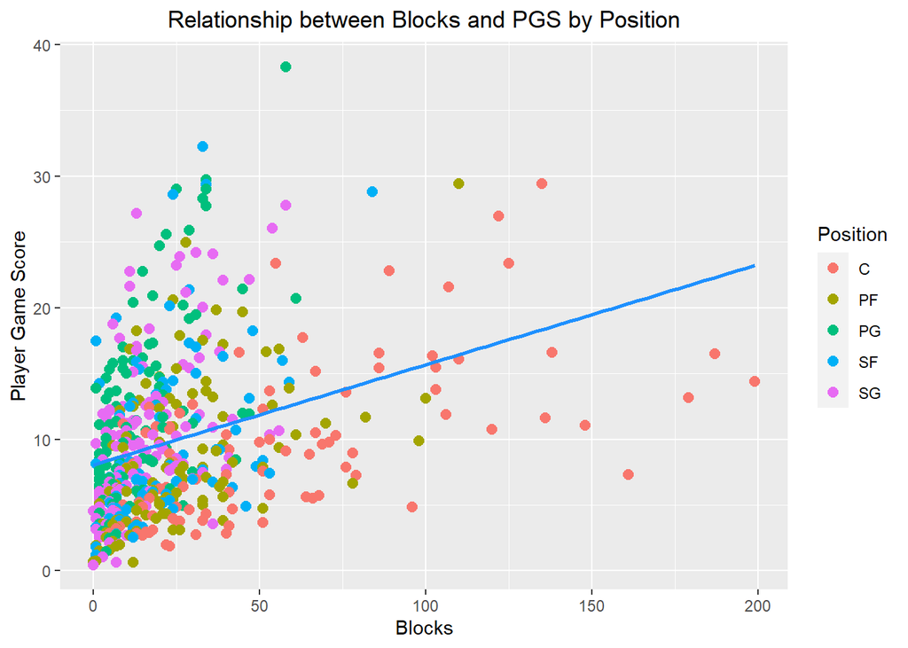

```r
ggplot(player_stats, aes(x = Blocks, y = Player_Game_Score, color = Position)) +
  geom_point(size = 2.5) +
   geom_smooth(method = "lm", color = "dodgerblue", se = FALSE)+
  xlab("Blocks") + ylab("Player Game Score") +
  ggtitle("Relationship between Blocks and PGS by Position") +
  theme(plot.title = element_text(hjust = 0.5))
```

## Pattern Description

### Statistical categories such as points, assists, blocks, steals play a crucial role in determining a player’s performance and contribution to the team.

### Players who score more tend to have a higher number of points, indicating a positive correlation between Point game score and points.Players to contribute significantly to their team’s point production and boost their overall efficiency.

### Player Game score and assists are positively correlated, as players who excel in passing and decision-making can create scoring opportunities for their team. By contributing to the team’s offensive efficiency, players can also positively impact their own efficiency rating.

### Player game score and blocks may be positively related, especially on the defensive end. Players who have the ability to block shots can provide a defensive advantage by defending scoring opportunities and intercepting offensive plays. Blocked shots can lead to turnovers and transition opportunities, which can positively impact a player’s overall score.

## Selecting the variable based on the analysis.

```r
Overall_player <- player_stats %>% select(player_name,Position, Games,
                                          Three_point_per, Two_point_per,
                                          Assists,Steals,Blocks,Total_Rebounds, Points, Player_Game_Score, game_score)
```

# 4.) Data Modelling

#### Data modeling is the process of creating a mathematical representation of a real-world system or situation, with the aim of understanding or predicting its behavior. It involves selecting and defining variables that are relevant to the system being studied, and using statistical methods to analyze the relationships between these variables and their effect on the outcome of interest.

#### The aim of data modeling in the context of player selection in NBA is to identify and analyze the statistical metrics that are most relevant in evaluating a player’s performance and predicting their future contributions to a team.

#### Once we had performed data visualization, we determined certain metrics that seemed significant in assessing the performance of players. These metrics were treated as the independent variables in our linear regression model, with the efficiency metric being the dependent variable.

#### The analysis aims to evaluate the effectiveness of the selected variables in predicting player efficiency. A close match between the observed and predicted values would indicate that the identified metrics are reliable indicators of player performance and can aid in determining their skill level.

```r
library(broom)
fitted <- lm(data= Overall_player,Player_Game_Score~Points++Assists+Blocks)
tidy(fitted,conf.int=TRUE)
```

```
## # A tibble: 4 × 7
##   term        estimate std.error statistic  p.value conf.low conf.high
##   <chr>          <dbl>     <dbl>     <dbl>    <dbl>    <dbl>     <dbl>
## 1 (Intercept)   2.64    0.193        13.7  1.16e-36  2.26      3.02
## 2 Points        0.0107  0.000430     24.9  7.05e-91  0.00988   0.0116
## 3 Assists       0.0104  0.00144       7.25 1.53e-12  0.00761   0.0133
## 4 Blocks       -0.0112  0.00471      -2.38 1.77e- 2 -0.0205   -0.00196
```

### A unit increase in points, player game score increases by 0.01

### A unit increase in assists, player game score increases by 0.01

### A unit increase in blocks, player game score decreases by 0.01

```r
summary(fitted)
```

```
##
## Call:
## lm(formula = Player_Game_Score ~ Points + +Assists + Blocks,
##     data = Overall_player)
##
## Residuals:
##     Min      1Q  Median      3Q     Max
## -4.1340 -1.7695 -0.6434  0.9642 13.5330
##
## Coefficients:
##               Estimate Std. Error t value Pr(>|t|)
## (Intercept)  2.6435084  0.1930971  13.690  < 2e-16 ***
## Points       0.0107285  0.0004304  24.928  < 2e-16 ***
## Assists      0.0104334  0.0014393   7.249 1.53e-12 ***
## Blocks      -0.0112204  0.0047140  -2.380   0.0177 *
## ---
## Signif. codes:  0 '***' 0.001 '**' 0.01 '*' 0.05 '.' 0.1 ' ' 1
##
## Residual standard error: 2.614 on 521 degrees of freedom
## Multiple R-squared:  0.829,  Adjusted R-squared:  0.828
## F-statistic: 841.9 on 3 and 521 DF,  p-value: < 2.2e-16
```

### What we can observe from the model

#### RSE measures the deviation of predicted Player game score from observed values, with a value of 2.614 in this model.

#### Multiple R-squared indicates that about 82% of the variation in game score per game.

#### The F-statistic of 841.9 and its associated p-value of p < 2.2e-16 provide strong evidence to reject the null hypothesis that all the regression coefficients are zero.

#### Overall, the model is statistically significant in explaining the variability in the dependent variable.

```r
Overall_player$predicted <- predict(fitted)

Overall_player$predicted <- round(Overall_player$predicted,2)

Overall_player <- Overall_player %>% arrange(desc(Overall_player$Player_Game_Score))
head(Overall_player)
```

```
## # A tibble: 6 × 13
##   player_name Posit…¹ Games Three…² Two_p…³ Assists Steals Blocks Total…⁴ Points
##   <chr>       <chr>   <dbl>   <dbl>   <dbl>   <dbl>  <dbl>  <dbl>   <dbl>  <dbl>
## 1 James Hard… PG         78   0.368   0.528     586    158     58     518   2818
## 2 LeBron Jam… SF         55   0.339   0.582     454     72     33     465   1505
## 3 Damian Lil… PG         80   0.369   0.499     551     88     34     371   2067
## 4 Anthony Da… C          56   0.331   0.547     218     88    135     672   1452
## 5 Giannis An… PF         72   0.256   0.641     424     92    110     898   1994
## 6 Paul George SF         77   0.386   0.484     318    170     34     628   2159
## # … with 3 more variables: Player_Game_Score <dbl>, game_score <dbl>,
## #   predicted <dbl>, and abbreviated variable names ¹Position,
## #   ²Three_point_per, ³Two_point_per, ⁴Total_Rebounds
```

# 5.) Player Recommendations

```r
#merging the players stats with salary.
stats_with_salary <- merge(Overall_player,player_salary,by="player_name")


stats_with_salary <- stats_with_salary %>% arrange(desc(stats_with_salary$Player_Game_Score))

head(stats_with_salary)
```

```
##             player_name Position Games Three_point_per Two_point_per Assists
## 1          James Harden       PG    78           0.368         0.528     586
## 2          LeBron James       SF    55           0.339         0.582     454
## 3        Damian Lillard       PG    80           0.369         0.499     551
## 4         Anthony Davis        C    56           0.331         0.547     218
## 5 Giannis Antetokounmpo       PF    72           0.256         0.641     424
## 6           Paul George       SF    77           0.386         0.484     318
##   Steals Blocks Total_Rebounds Points Player_Game_Score game_score predicted
## 1    158     58            518   2818          38.32051       2989     38.34
## 2     72     33            465   1505          32.23636       1773     23.16
## 3     88     34            371   2067          29.75000       2380     30.19
## 4     88    135            672   1452          29.44643       1649     18.98
## 5     92    110            898   1994          29.44444       2120     27.23
## 6    170     34            628   2159          29.37662       2262     28.74
##   player_id   salary
## 1       224 30570000
## 2       278 35654150
## 3       328 27977689
## 4       135 25434263
## 5        20 24157304
## 6       197 30560700
```

```r
final_data <- stats_with_salary %>% select(player_name,player_id,Position,
 Three_point_per,Two_point_per,
Points,
Assists,
Blocks,
Steals,
salary,
Player_Game_Score)

head(final_data)
```

```
##             player_name player_id Position Three_point_per Two_point_per Points
## 1          James Harden       224       PG           0.368         0.528   2818
## 2          LeBron James       278       SF           0.339         0.582   1505
## 3        Damian Lillard       328       PG           0.369         0.499   2067
## 4         Anthony Davis       135        C           0.331         0.547   1452
## 5 Giannis Antetokounmpo        20       PF           0.256         0.641   1994
## 6           Paul George       197       SF           0.386         0.484   2159
##   Assists Blocks Steals   salary Player_Game_Score
## 1     586     58    158 30570000          38.32051
## 2     454     33     72 35654150          32.23636
## 3     551     34     88 27977689          29.75000
## 4     218    135     88 25434263          29.44643
## 5     424    110     92 24157304          29.44444
## 6     318     34    170 30560700          29.37662
```

### Selecting the player

```r
Selection_final <- final_data %>% select(player_name,
 Position, Points, Assists,
Player_Game_Score,
salary)
head(Selection_final,20)
```

```
##              player_name Position Points Assists Player_Game_Score   salary
## 1           James Harden       PG   2818     586          38.32051 30570000
## 2           LeBron James       SF   1505     454          32.23636 35654150
## 3         Damian Lillard       PG   2067     551          29.75000 27977689
## 4          Anthony Davis        C   1452     218          29.44643 25434263
## 5  Giannis Antetokounmpo       PF   1994     424          29.44444 24157304
## 6            Paul George       SF   2159     318          29.37662 30560700
## 7           Kemba Walker       PG   2102     484          29.02439 12000000
## 8          Stephen Curry       PG   1881     361          29.00000 37457154
## 9           Kevin Durant       SF   2027     457          28.79487 30000000
## 10         Kawhi Leonard       SF   1596     199          28.61667 23114066
## 11     Russell Westbrook       PG   1675     784          28.27397 35665000
## 12          Bradley Beal       SG   2099     448          27.75610 25434262
## 13          Kyrie Irving       PG   1596     464          27.73134 20099189
## 14          Devin Booker       SG   1700     433          27.15625  3314365
## 15           Joel Embiid        C   1761     234          26.96875 25467250
## 16          Jrue Holiday       SG   1420     518          26.01493 26641111
## 17             John Wall       PG    663     279          25.87500 19169800
## 18           Mike Conley       PG   1478     449          25.57143 30521115
## 19         Blake Griffin       PF   1841     402          24.94667 31873932
## 20      D'Angelo Russell       PG   1712     563          24.70370  7019698
```

```r
unique(Selection_final$Position)
```

```
## [1] "PG" "SF" "C"  "PF" "SG"
```

## Selecting one player for each position

```r
Selection_final %>% filter(Position=="SG") %>% arrange(desc(Player_Game_Score))
```

```
##                  player_name Position Points Assists Player_Game_Score   salary
## 1               Bradley Beal       SG   2099     448        27.7560976 25434262
## 2               Devin Booker       SG   1700     433        27.1562500  3314365
## 3               Jrue Holiday       SG   1420     518        26.0149254 26641111
## 4           Donovan Mitchell       SG   1829     322        24.1818182  3111480
## 5              DeMar DeRozan       SG   1635     475        24.1038961 27739975
## 6                Zach LaVine       SG   1492     283        23.9047619 19500000
## 7                Luka Doncic       SG   1526     429        23.2361111  6569040
## 8              Klay Thompson       SG   1680     186        22.1153846 18988725
## 9               Jimmy Butler       SG   1215     263        22.0615385 19841627
## 10            Victor Oladipo       SG    675     186        21.6111111 21000000
## 11               CJ McCollum       SG   1468     207        21.1428571 25759766
## 12               Buddy Hield       SG   1695     205        20.0365854  3833760
## 13              Tim Hardaway       SG    880     122        18.7608696 17325000
## 14                 JJ Redick       SG   1372     206        18.3815789 12250000
```

[output cut: 112 more lines]

```r
Selection_final %>% filter(Position=="C") %>% arrange(desc(Player_Game_Score))
```

```
##            player_name Position Points Assists Player_Game_Score   salary
## 1        Anthony Davis        C   1452     218         29.446429 25434263
## 2          Joel Embiid        C   1761     234         26.968750 25467250
## 3         Nikola Jokic        C   1604     580         23.387500 25467250
## 4   Karl-Anthony Towns        C   1880     259         23.363636  7839435
## 5       Nikola Vucevic        C   1665     307         22.825000 12750000
## 6    LaMarcus Aldridge        C   1727     194         21.580247 22347015
## 7           Marc Gasol        C    834     248         17.716981 24119025
## 8     DeMarcus Cousins        C    488     107         16.600000  5337000
## 9       Andre Drummond        C   1370     112         16.569620 25434262
## 10          Al Horford        C    925     283         16.544118 28928710
## 11         Rudy Gobert        C   1284     161         16.506173 23491573
## 12        Clint Capela        C   1114      96         16.328358 15793104
## 13    Montrezl Harrell        C   1361     162         16.060976  6000000
## 14        Jusuf Nurkic        C   1125     233         15.472222 11111111
```

[output cut: 80 more lines]

```r
Selection_final %>% filter(Position=="SF") %>% arrange(desc(Player_Game_Score))
```

```
##                player_name Position Points Assists Player_Game_Score   salary
## 1             LeBron James       SF   1505     454         32.236364 35654150
## 2              Paul George       SF   2159     318         29.376623 30560700
## 3             Kevin Durant       SF   2027     457         28.794872 30000000
## 4            Kawhi Leonard       SF   1596     199         28.616667 23114066
## 5             Jimmy Butler       SF   1215     263         22.061538 19841627
## 6             Jimmy Butler       SF   1002     220         21.381818 19841627
## 7         Danilo Gallinari       SF   1346     178         20.117647 21587579
## 8          Khris Middleton       SF   1407     331         19.207792 13000000
## 9           Andrew Wiggins       SF   1321     184         18.246575 25467250
## 10        Bojan Bogdanovic       SF   1454     161         17.444444 10500000
## 11               TJ Warren       SF    772      64         17.325581 11750000
## 12          Brandon Ingram       SF    950     154         17.019231  5757120
## 13             Kelly Oubre       SF    674      64         16.275000  3208630
## 14            Jayson Tatum       SF   1243     168         15.974684  6700800
```

[output cut: 70 more lines]

```r
Selection_final %>% filter(Position=="PF") %>% arrange(desc(Player_Game_Score))
```

```
##                player_name Position Points Assists Player_Game_Score   salary
## 1    Giannis Antetokounmpo       PF   1994     424        29.4444444 24157304
## 2            Blake Griffin       PF   1841     402        24.9466667 31873932
## 3            Tobias Harris       PF   1152     150        20.6181818 14800000
## 4            Tobias Harris       PF   1644     229        19.8292683 14800000
## 5            Julius Randle       PF   1565     229        19.6849315  8641000
## 6            Tobias Harris       PF    492      79        18.2222222 14800000
## 7               Kyle Kuzma       PF   1308     178        17.8571429  1689840
## 8          Lauri Markkanen       PF    974      75        17.5384615  4536120
## 9             John Collins       PF   1188     121        17.2295082  2299080
## 10            Aaron Gordon       PF   1246     289        16.8461538 21590909
## 11         Harrison Barnes       PF    866      62        16.8367347 24107258
## 12           Pascal Siakam       PF   1354     248        16.6500000  1544951
## 13         Harrison Barnes       PF   1265     115        15.8831169 24107258
## 14          Nikola Mirotic       PF    534      35        15.3750000 12500000
```

[output cut: 93 more lines]

```r
Selection_final %>% filter(Position=="PG") %>% arrange(desc(Player_Game_Score))
```

```
##                 player_name Position Points Assists Player_Game_Score   salary
## 1              James Harden       PG   2818     586         38.320513 30570000
## 2            Damian Lillard       PG   2067     551         29.750000 27977689
## 3              Kemba Walker       PG   2102     484         29.024390 12000000
## 4             Stephen Curry       PG   1881     361         29.000000 37457154
## 5         Russell Westbrook       PG   1675     784         28.273973 35665000
## 6              Kyrie Irving       PG   1596     464         27.731343 20099189
## 7                 John Wall       PG    663     279         25.875000 19169800
## 8               Mike Conley       PG   1478     449         25.571429 30521115
## 9          D'Angelo Russell       PG   1712     563         24.703704  7019698
## 10               Trae Young       PG   1549     653         22.728395  5363280
## 11             De'Aaron Fox       PG   1399     590         21.432099  5470920
## 12               Chris Paul       PG    906     473         20.913793 35654150
## 13              Ben Simmons       PG   1337     610         20.721519  6434520
## 14             Derrick Rose       PG    917     220         20.411765  2176260
```

[output cut: 86 more lines]

# CHICAGO BULLS 5 players for the season 2019-20

**SHOOTING GUARD**

### Playername : BRADLEY BEAL

#### Points :2099

#### Assists : 448

#### Player_Game_Score :27

**POINT GUARD**

#### Playername : JAMES HARDEN

#### Points :2818

#### Assists :586

#### Player_Game_Score :38

**CENTER**

#### Playername : ANTONY DAVIES

#### Points :1452

#### Assists :218

#### Player_Game_Score :29

**POWER FORWARD**

#### Playername : GIANNIS ANTETOKOUNMPO

#### Points :1994

#### Assists :424

#### Player_Game_Score :29

**SMALL FORWARD**

#### Playername : LEBRON JAMES

#### Points :1505

#### Assists :454

#### Player_Game_Score :32